# wrangle_act

I will analyze a twitter account called 'WeRateDogs'

## Table of content:

- Introduction
- Gathering Data
- Assessing Data
- Cleaning Data
- Storing Data
- Visualization

### Introduction

On this project I'll be analyzing a twitter account called 'WeRateDogs'. First we must collect three dataset for this project to succeed, the dataset are:

- twitter-archive-enhanced.csv
- image-predictions.tsv
- tweet-json.txt

### Gathering Data:

we need to import the needed library

```python
# import library statements
import pandas as pd
import numpy as np
import requests
import json
import os
import tweepy
```

the code below is to read the .csv file we are going to analyze

```python
rd = pd.read_csv(r'twitter-archive-enhanced-2.csv')
rd.head(5)
```

|  | tweet_id | in_reply_to_status_id | in_reply_to_user_id | timestamp | source | text | retweeted_status_id | retweeted_status_user_id | retweeted_status_timestamp | expanded_urls | rating_numerator | rating_denominator | name | doggo | floofer | pupper | puppo |
| --- | --- | --- | --- | --- | --- | --- | --- | --- | --- | --- | --- | --- | --- | --- | --- | --- | --- |
| 0 | 892420643555336193 | NaN | NaN | 2017-08-01 16:23:56 +0000 | <a href="http://twitter.com/download/iphone" r... | This is Phineas. He's a mystical boy. Only eve... | NaN | NaN | NaN | https://twitter.com/dog_rates/status/892420643... | 13 | 10 | Phineas | None | None | None | None |
| 1 | 892177421306343426 | NaN | NaN | 2017-08-01 00:17:27 +0000 | <a href="http://twitter.com/download/iphone" r... | This is Tilly. She's just checking pup on you.... | NaN | NaN | NaN | https://twitter.com/dog_rates/status/892177421... | 13 | 10 | Tilly | None | None | None | None |
| 2 | 891815181378084864 | NaN | NaN | 2017-07-31 00:18:03 +0000 | <a href="http://twitter.com/download/iphone" r... | This is Archie. He is a rare Norwegian Pouncin... | NaN | NaN | NaN | https://twitter.com/dog_rates/status/891815181... | 12 | 10 | Archie | None | None | None | None |
| 3 | 891689557279858688 | NaN | NaN | 2017-07-30 15:58:51 +0000 | <a href="http://twitter.com/download/iphone" r... | This is Darla. She commenced a snooze mid meal... | NaN | NaN | NaN | https://twitter.com/dog_rates/status/891689557... | 13 | 10 | Darla | None | None | None | None |
| 4 | 891327558926688256 | NaN | NaN | 2017-07-29 16:00:24 +0000 | <a href="http://twitter.com/download/iphone" r... | This is Franklin. He would like you to stop ca... | NaN | NaN | NaN | https://twitter.com/dog_rates/status/891327558... | 12 | 10 | Franklin | None | None | None | None |

download the .tsv file through `request` library

```python
url = 'https://d17h27t6h515a5.cloudfront.net/topher/2017/August/599fd2ad_image-predictions/image-predictions.tsv'
response = requests.get(url)
with open(url.split('/')[-1], mode='wb') as file:
    file.write(response.content)
```

open the .tsv file

```python
open('image-predictions.tsv', 'wb').write(response.content)
```

```
335079
```

```python
image_prediction = pd.read_csv('image-predictions.tsv')
image_prediction.head()
```

|  | tweet_id jpg_url img_num p1 p1_conf p1_dog p2 p2_conf p2_dog p3 p3_conf p3_dog |
| --- | --- |
| 0 | 666020888022790149\thttps://pbs.twimg.com/medi... |
| 1 | 666029285002620928\thttps://pbs.twimg.com/medi... |
| 2 | 666033412701032449\thttps://pbs.twimg.com/medi... |
| 3 | 666044226329800704\thttps://pbs.twimg.com/medi... |
| 4 | 666049248165822465\thttps://pbs.twimg.com/medi... |

```python
image_prediction = pd.read_csv('image-predictions.tsv', sep = '\t')
image_prediction.head()
```

|  | tweet_id | jpg_url | img_num | p1 | p1_conf | p1_dog | p2 | p2_conf | p2_dog | p3 | p3_conf | p3_dog |
| --- | --- | --- | --- | --- | --- | --- | --- | --- | --- | --- | --- | --- |
| 0 | 666020888022790149 | https://pbs.twimg.com/media/CT4udn0WwAA0aMy.jpg | 1 | Welsh_springer_spaniel | 0.465074 | True | collie | 0.156665 | True | Shetland_sheepdog | 0.061428 | True |
| 1 | 666029285002620928 | https://pbs.twimg.com/media/CT42GRgUYAA5iDo.jpg | 1 | redbone | 0.506826 | True | miniature_pinscher | 0.074192 | True | Rhodesian_ridgeback | 0.072010 | True |
| 2 | 666033412701032449 | https://pbs.twimg.com/media/CT4521TWwAEvMyu.jpg | 1 | German_shepherd | 0.596461 | True | malinois | 0.138584 | True | bloodhound | 0.116197 | True |
| 3 | 666044226329800704 | https://pbs.twimg.com/media/CT5Dr8HUEAA-lEu.jpg | 1 | Rhodesian_ridgeback | 0.408143 | True | redbone | 0.360687 | True | miniature_pinscher | 0.222752 | True |
| 4 | 666049248165822465 | https://pbs.twimg.com/media/CT5IQmsXIAAKY4A.jpg | 1 | miniature_pinscher | 0.560311 | True | Rottweiler | 0.243682 | True | Doberman | 0.154629 | True |

twitter_API

```python
import tweepy
from tweepy import OAuthHandler
import json
from timeit import default_timer as timer

# Query Twitter API for each tweet in the Twitter archive and save JSON in a text file
# These are hidden to comply with Twitter's API terms and conditions
consumer_key = 'HIDDEN'
consumer_secret = 'HIDDEN'
access_token = 'HIDDEN'
access_secret = 'HIDDEN'

auth = OAuthHandler(consumer_key, consumer_secret)
auth.set_access_token(access_token, access_secret)

#auth = tweepy.OAuthHandler('5Uur0mo4ol2kB8yhtZ1VxXS0u', 'h8E7fSpXWiMoBel7G1ZOAeu4Mgru0v0MtxH5ehYE1RKM89SiBH')
#auth.set_access_token('303562412-ct9aNnU0FQR0UKJVn1i1W3Y8omqSewiQWUcRaygB', 'D3qslrbdOU5fqTOp951kOIuZbkeTPBodnjNYoEGFR63Ft')


api = tweepy.API(auth, wait_on_rate_limit=True)

tweet_ids = rd.tweet_id.values
len(tweet_ids)

# Query Twitter's API for JSON data for each tweet ID in the Twitter archive
count = 0
fails_dict = {}
start = timer()
# Save each tweet's returned JSON as a new line in a .txt file
with open('tweet_json.txt', 'w') as outfile:
    # This loop will likely take 20-30 minutes to run because of Twitter's rate limit
    for tweet_id in tweet_ids:
        count += 1
        print(str(count) + ": " + str(tweet_id))
        try:
            tweet = api.get_status(tweet_id, tweet_mode='extended')
            print("Success")
            json.dump(tweet._json, outfile)
            outfile.write('\n')
        except tweepy.errors.TweepyException as e:
            print("Fail")
            fails_dict[tweet_id] = e
            pass
end = timer()
print(end - start)
print(fails_dict)
```

[output not shown]

[output cut: 4659 more lines]

[output not shown]

to import the 'json' file

```python
import json


data_list = []

with open('tweet-json.txt') as json_file:
    for line in json_file:
        data_list.append(json.loads(line))


data_list[0]
```

```
{'created_at': 'Tue Aug 01 16:23:56 +0000 2017',
 'id': 892420643555336193,
 'id_str': '892420643555336193',
 'full_text': "This is Phineas. He's a mystical boy. Only ever appears in the hole of a donut. 13/10 https://t.co/MgUWQ76dJU",
 'truncated': False,
 'display_text_range': [0, 85],
 'entities': {'hashtags': [],
  'symbols': [],
  'user_mentions': [],
  'urls': [],
  'media': [{'id': 892420639486877696,
    'id_str': '892420639486877696',
    'indices': [86, 109],
    'media_url': 'http://pbs.twimg.com/media/DGKD1-bXoAAIAUK.jpg',
    'media_url_https': 'https://pbs.twimg.com/media/DGKD1-bXoAAIAUK.jpg',
    'url': 'https://t.co/MgUWQ76dJU',
    'display_url': 'pic.twitter.com/MgUWQ76dJU',
    'expanded_url': 'https://twitter.com/dog_rates/status/892420643555336193/photo/1',
    'type': 'photo',
    'sizes': {'large': {'w': 540, 'h': 528, 'resize': 'fit'},
     'thumb': {'w': 150, 'h': 150, 'resize': 'crop'},
     'small': {'w': 540, 'h': 528, 'resize': 'fit'},
     'medium': {'w': 540, 'h': 528, 'resize': 'fit'}}}]},
 'extended_entities': {'media': [{'id': 892420639486877696,
    'id_str': '892420639486877696',
    'indices': [86, 109],
    'media_url': 'http://pbs.twimg.com/media/DGKD1-bXoAAIAUK.jpg',
    'media_url_https': 'https://pbs.twimg.com/media/DGKD1-bXoAAIAUK.jpg',
    'url': 'https://t.co/MgUWQ76dJU',
    'display_url': 'pic.twitter.com/MgUWQ76dJU',
    'expanded_url': 'https://twitter.com/dog_rates/status/892420643555336193/photo/1',
    'type': 'photo',
    'sizes': {'large': {'w': 540, 'h': 528, 'resize': 'fit'},
     'thumb': {'w': 150, 'h': 150, 'resize': 'crop'},
     'small': {'w': 540, 'h': 528, 'resize': 'fit'},
     'medium': {'w': 540, 'h': 528, 'resize': 'fit'}}}]},
 'source': '<a href="http://twitter.com/download/iphone" rel="nofollow">Twitter for iPhone</a>',
 'in_reply_to_status_id': None,
 'in_reply_to_status_id_str': None,
 'in_reply_to_user_id': None,
```

[output cut: 45 more lines]

```
  'follow_request_sent': False,
  'notifications': False,
  'translator_type': 'none'},
 'geo': None,
 'coordinates': None,
 'place': None,
 'contributors': None,
 'is_quote_status': False,
 'retweet_count': 8853,
 'favorite_count': 39467,
 'favorited': False,
 'retweeted': False,
 'possibly_sensitive': False,
 'possibly_sensitive_appealable': False,
 'lang': 'en'}
```

store it on a DataFrame

```python
json_tweet = pd.DataFrame(data_list)
```

```python
json_data_list=[]
for i in data_list:
    tweet_id = i['id']
    retweet_count = i['retweet_count']
    favorite_count = i['favorite_count']
    json_data_list.append({'id':tweet_id , 'retweet_count': retweet_count , 'favorite_count': favorite_count})
```

```python
j_df = pd.DataFrame(json_data_list , columns = ['id' , 'retweet_count' , 'favorite_count'])

j_df.shape
```

```
(2354, 3)
```

read the first five rows

```python
j_df.head()
```

|  | id | retweet_count | favorite_count |
| --- | --- | --- | --- |
| 0 | 892420643555336193 | 8853 | 39467 |
| 1 | 892177421306343426 | 6514 | 33819 |
| 2 | 891815181378084864 | 4328 | 25461 |
| 3 | 891689557279858688 | 8964 | 42908 |
| 4 | 891327558926688256 | 9774 | 41048 |

### Assessing Data:

print the shape and the information about the dataset

```python
print('- DataFrame shape = ',rd.shape)
print()
print('- DataFrame information:-')
print(rd.info())
```

```
- DataFrame shape =  (2356, 17)

- DataFrame information:-
<class 'pandas.core.frame.DataFrame'>
RangeIndex: 2356 entries, 0 to 2355
Data columns (total 17 columns):
tweet_id                      2356 non-null int64
in_reply_to_status_id         78 non-null float64
in_reply_to_user_id           78 non-null float64
timestamp                     2356 non-null object
source                        2356 non-null object
text                          2356 non-null object
retweeted_status_id           181 non-null float64
retweeted_status_user_id      181 non-null float64
retweeted_status_timestamp    181 non-null object
expanded_urls                 2297 non-null object
rating_numerator              2356 non-null int64
rating_denominator            2356 non-null int64
name                          2356 non-null object
doggo                         2356 non-null object
floofer                       2356 non-null object
pupper                        2356 non-null object
puppo                         2356 non-null object
dtypes: float64(4), int64(3), object(10)
memory usage: 313.0+ KB
None
```

print the information about the dataset

```python
image_prediction.info()
```

```
<class 'pandas.core.frame.DataFrame'>
RangeIndex: 2075 entries, 0 to 2074
Data columns (total 12 columns):
tweet_id    2075 non-null int64
jpg_url     2075 non-null object
img_num     2075 non-null int64
p1          2075 non-null object
p1_conf     2075 non-null float64
p1_dog      2075 non-null bool
p2          2075 non-null object
p2_conf     2075 non-null float64
p2_dog      2075 non-null bool
p3          2075 non-null object
p3_conf     2075 non-null float64
p3_dog      2075 non-null bool
dtypes: bool(3), float64(3), int64(2), object(4)
memory usage: 152.1+ KB
```

print the information about the dataset

```python
json_tweet.info()
```

```
<class 'pandas.core.frame.DataFrame'>
RangeIndex: 2354 entries, 0 to 2353
Data columns (total 31 columns):
contributors                     0 non-null object
coordinates                      0 non-null object
created_at                       2354 non-null object
display_text_range               2354 non-null object
entities                         2354 non-null object
extended_entities                2073 non-null object
favorite_count                   2354 non-null int64
favorited                        2354 non-null bool
full_text                        2354 non-null object
geo                              0 non-null object
id                               2354 non-null int64
id_str                           2354 non-null object
in_reply_to_screen_name          78 non-null object
in_reply_to_status_id            78 non-null float64
in_reply_to_status_id_str        78 non-null object
in_reply_to_user_id              78 non-null float64
in_reply_to_user_id_str          78 non-null object
is_quote_status                  2354 non-null bool
lang                             2354 non-null object
place                            1 non-null object
possibly_sensitive               2211 non-null object
possibly_sensitive_appealable    2211 non-null object
quoted_status                    28 non-null object
quoted_status_id                 29 non-null float64
quoted_status_id_str             29 non-null object
retweet_count                    2354 non-null int64
retweeted                        2354 non-null bool
retweeted_status                 179 non-null object
source                           2354 non-null object
truncated                        2354 non-null bool
user                             2354 non-null object
dtypes: bool(4), float64(3), int64(3), object(21)
memory usage: 505.8+ KB
```

read the first three rows from the .csv file

```python
rd.head(3)
```

|  | tweet_id | in_reply_to_status_id | in_reply_to_user_id | timestamp | source | text | retweeted_status_id | retweeted_status_user_id | retweeted_status_timestamp | expanded_urls | rating_numerator | rating_denominator | name | doggo | floofer | pupper | puppo |
| --- | --- | --- | --- | --- | --- | --- | --- | --- | --- | --- | --- | --- | --- | --- | --- | --- | --- |
| 0 | 892420643555336193 | NaN | NaN | 2017-08-01 16:23:56 +0000 | <a href="http://twitter.com/download/iphone" r... | This is Phineas. He's a mystical boy. Only eve... | NaN | NaN | NaN | https://twitter.com/dog_rates/status/892420643... | 13 | 10 | Phineas | None | None | None | None |
| 1 | 892177421306343426 | NaN | NaN | 2017-08-01 00:17:27 +0000 | <a href="http://twitter.com/download/iphone" r... | This is Tilly. She's just checking pup on you.... | NaN | NaN | NaN | https://twitter.com/dog_rates/status/892177421... | 13 | 10 | Tilly | None | None | None | None |
| 2 | 891815181378084864 | NaN | NaN | 2017-07-31 00:18:03 +0000 | <a href="http://twitter.com/download/iphone" r... | This is Archie. He is a rare Norwegian Pouncin... | NaN | NaN | NaN | https://twitter.com/dog_rates/status/891815181... | 12 | 10 | Archie | None | None | None | None |

```python
image_prediction.head()
```

|  | tweet_id | jpg_url | img_num | p1 | p1_conf | p1_dog | p2 | p2_conf | p2_dog | p3 | p3_conf | p3_dog |
| --- | --- | --- | --- | --- | --- | --- | --- | --- | --- | --- | --- | --- |
| 0 | 666020888022790149 | https://pbs.twimg.com/media/CT4udn0WwAA0aMy.jpg | 1 | Welsh_springer_spaniel | 0.465074 | True | collie | 0.156665 | True | Shetland_sheepdog | 0.061428 | True |
| 1 | 666029285002620928 | https://pbs.twimg.com/media/CT42GRgUYAA5iDo.jpg | 1 | redbone | 0.506826 | True | miniature_pinscher | 0.074192 | True | Rhodesian_ridgeback | 0.072010 | True |
| 2 | 666033412701032449 | https://pbs.twimg.com/media/CT4521TWwAEvMyu.jpg | 1 | German_shepherd | 0.596461 | True | malinois | 0.138584 | True | bloodhound | 0.116197 | True |
| 3 | 666044226329800704 | https://pbs.twimg.com/media/CT5Dr8HUEAA-lEu.jpg | 1 | Rhodesian_ridgeback | 0.408143 | True | redbone | 0.360687 | True | miniature_pinscher | 0.222752 | True |
| 4 | 666049248165822465 | https://pbs.twimg.com/media/CT5IQmsXIAAKY4A.jpg | 1 | miniature_pinscher | 0.560311 | True | Rottweiler | 0.243682 | True | Doberman | 0.154629 | True |

read the first three rows from json_tweet file

```python
json_tweet.head(3)
```

|  | contributors | coordinates | created_at | display_text_range | entities | extended_entities | favorite_count | favorited | full_text | geo | ... | possibly_sensitive_appealable | quoted_status | quoted_status_id | quoted_status_id_str | retweet_count | retweeted | retweeted_status | source | truncated | user |
| --- | --- | --- | --- | --- | --- | --- | --- | --- | --- | --- | --- | --- | --- | --- | --- | --- | --- | --- | --- | --- | --- |
| 0 | None | None | Tue Aug 01 16:23:56 +0000 2017 | [0, 85] | {'hashtags': [], 'symbols': [], 'user_mentions... | {'media': [{'id': 892420639486877696, 'id_str'... | 39467 | False | This is Phineas. He's a mystical boy. Only eve... | None | ... | False | NaN | NaN | NaN | 8853 | False | NaN | <a href="http://twitter.com/download/iphone" r... | False | {'id': 4196983835, 'id_str': '4196983835', 'na... |
| 1 | None | None | Tue Aug 01 00:17:27 +0000 2017 | [0, 138] | {'hashtags': [], 'symbols': [], 'user_mentions... | {'media': [{'id': 892177413194625024, 'id_str'... | 33819 | False | This is Tilly. She's just checking pup on you.... | None | ... | False | NaN | NaN | NaN | 6514 | False | NaN | <a href="http://twitter.com/download/iphone" r... | False | {'id': 4196983835, 'id_str': '4196983835', 'na... |
| 2 | None | None | Mon Jul 31 00:18:03 +0000 2017 | [0, 121] | {'hashtags': [], 'symbols': [], 'user_mentions... | {'media': [{'id': 891815175371796480, 'id_str'... | 25461 | False | This is Archie. He is a rare Norwegian Pouncin... | None | ... | False | NaN | NaN | NaN | 4328 | False | NaN | <a href="http://twitter.com/download/iphone" r... | False | {'id': 4196983835, 'id_str': '4196983835', 'na... |

3 rows × 31 columns

number of null values in each column for each dataset

```python
rd.isnull().sum()
```

```
tweet_id                         0
in_reply_to_status_id         2278
in_reply_to_user_id           2278
timestamp                        0
source                           0
text                             0
retweeted_status_id           2175
retweeted_status_user_id      2175
retweeted_status_timestamp    2175
expanded_urls                   59
rating_numerator                 0
rating_denominator               0
name                             0
doggo                            0
floofer                          0
pupper                           0
puppo                            0
dtype: int64
```

```python
image_prediction.isnull().sum()
```

```
tweet_id    0
jpg_url     0
img_num     0
p1          0
p1_conf     0
p1_dog      0
p2          0
p2_conf     0
p2_dog      0
p3          0
p3_conf     0
p3_dog      0
dtype: int64
```

```python
json_tweet.isnull().sum()
```

```
contributors                     2354
coordinates                      2354
created_at                          0
display_text_range                  0
entities                            0
extended_entities                 281
favorite_count                      0
favorited                           0
full_text                           0
geo                              2354
id                                  0
id_str                              0
in_reply_to_screen_name          2276
in_reply_to_status_id            2276
in_reply_to_status_id_str        2276
in_reply_to_user_id              2276
in_reply_to_user_id_str          2276
is_quote_status                     0
lang                                0
place                            2353
possibly_sensitive                143
possibly_sensitive_appealable     143
quoted_status                    2326
quoted_status_id                 2325
quoted_status_id_str             2325
retweet_count                       0
retweeted                           0
retweeted_status                 2175
source                              0
truncated                           0
user                                0
dtype: int64
```

the number of unique values:

```python
rd.nunique()
```

```
tweet_id                      2356
in_reply_to_status_id           77
in_reply_to_user_id             31
timestamp                     2356
source                           4
text                          2356
retweeted_status_id            181
retweeted_status_user_id        25
retweeted_status_timestamp     181
expanded_urls                 2218
rating_numerator                40
rating_denominator              18
name                           957
doggo                            2
floofer                          2
pupper                           2
puppo                            2
dtype: int64
```

count the number of unique values on the dataset:

```python
rd.nunique().sum()
```

```
10808
```

count each value on 'rating_denominator' and 'rating_numerator' columns

```python
rd.rating_denominator.value_counts()
```

```
10     2333
11        3
50        3
80        2
20        2
2         1
16        1
40        1
70        1
15        1
90        1
110       1
120       1
130       1
150       1
170       1
7         1
0         1
Name: rating_denominator, dtype: int64
```

```python
rd.rating_numerator.value_counts()
```

```
12      558
11      464
10      461
13      351
9       158
8       102
7        55
14       54
5        37
6        32
3        19
4        17
1         9
2         9
420       2
```

[output cut: 26 more lines]

number of unique values on the important columns:

count the number of values on the important columns:

```python
rd.name.unique()
```

```
array(['Phineas', 'Tilly', 'Archie', 'Darla', 'Franklin', 'None', 'Jax',
       'Zoey', 'Cassie', 'Koda', 'Bruno', 'Ted', 'Stuart', 'Oliver',
       'Jim', 'Zeke', 'Ralphus', 'Canela', 'Gerald', 'Jeffrey', 'such',
       'Maya', 'Mingus', 'Derek', 'Roscoe', 'Waffles', 'Jimbo', 'Maisey',
       'Lilly', 'Earl', 'Lola', 'Kevin', 'Yogi', 'Noah', 'Bella',
       'Grizzwald', 'Rusty', 'Gus', 'Stanley', 'Alfy', 'Koko', 'Rey',
       'Gary', 'a', 'Elliot', 'Louis', 'Jesse', 'Romeo', 'Bailey',
       'Duddles', 'Jack', 'Emmy', 'Steven', 'Beau', 'Snoopy', 'Shadow',
       'Terrance', 'Aja', 'Penny', 'Dante', 'Nelly', 'Ginger', 'Benedict',
       'Venti', 'Goose', 'Nugget', 'Cash', 'Coco', 'Jed', 'Sebastian',
       'Walter', 'Sierra', 'Monkey', 'Harry', 'Kody', 'Lassie', 'Rover',
       'Napolean', 'Dawn', 'Boomer', 'Cody', 'Rumble', 'Clifford',
       'quite', 'Dewey', 'Scout', 'Gizmo', 'Cooper', 'Harold', 'Shikha',
       'Jamesy', 'Lili', 'Sammy', 'Meatball', 'Paisley', 'Albus',
       'Neptune', 'Quinn', 'Belle', 'Zooey', 'Dave', 'Jersey', 'Hobbes',
       'Burt', 'Lorenzo', 'Carl', 'Jordy', 'Milky', 'Trooper', 'Winston',
       'Sophie', 'Wyatt', 'Rosie', 'Thor', 'Oscar', 'Luna', 'Callie',
       'Cermet', 'George', 'Marlee', 'Arya', 'Einstein', 'Alice',
       'Rumpole', 'Benny', 'Aspen', 'Jarod', 'Wiggles', 'General',
       'Sailor', 'Astrid', 'Iggy', 'Snoop', 'Kyle', 'Leo', 'Riley',
       'Gidget', 'Noosh', 'Odin', 'Jerry', 'Charlie', 'Georgie', 'Rontu',
       'Cannon', 'Furzey', 'Daisy', 'Tuck', 'Barney', 'Vixen', 'Jarvis',
       'Mimosa', 'Pickles', 'Bungalo', 'Brady', 'Margo', 'Sadie', 'Hank',
       'Tycho', 'Stephan', 'Indie', 'Winnie', 'Bentley', 'Ken', 'Max',
       'Maddie', 'Pipsy', 'Monty', 'Sojourner', 'Odie', 'Arlo', 'Sunny',
       'Vincent', 'Lucy', 'Clark', 'Mookie', 'Meera', 'Buddy', 'Ava',
       'Rory', 'Eli', 'Ash', 'Tucker', 'Tobi', 'Chester', 'Wilson',
       'Sunshine', 'Lipton', 'Gabby', 'Bronte', 'Poppy', 'Rhino',
       'Willow', 'not', 'Orion', 'Eevee', 'Smiley', 'Logan', 'Moreton',
       'Klein', 'Miguel', 'Emanuel', 'Kuyu', 'Dutch', 'Pete', 'Scooter',
       'Reggie', 'Kyro', 'Samson', 'Loki', 'Mia', 'Malcolm', 'Dexter',
       'Alfie', 'Fiona', 'one', 'Mutt', 'Bear', 'Doobert', 'Beebop',
       'Alexander', 'Sailer', 'Brutus', 'Kona', 'Boots', 'Ralphie',
       'Phil', 'Cupid', 'Pawnd', 'Pilot', 'Ike', 'Mo', 'Toby', 'Sweet',
       'Pablo', 'Nala', 'Balto', 'Crawford', 'Gabe', 'Mattie', 'Jimison',
       'Hercules', 'Duchess', 'Harlso', 'Sampson', 'Sundance', 'Luca',
       'Flash', 'Finn', 'Peaches', 'Howie', 'Jazzy', 'Anna', 'Bo',
       'Seamus', 'Wafer', 'Chelsea', 'Tom', 'Moose', 'Florence', 'Autumn',
       'Dido', 'Eugene', 'Herschel', 'Strudel', 'Tebow', 'Chloe', 'Betty',
       'Timber', 'Binky', 'Dudley', 'Comet', 'Larry', 'Levi', 'Akumi',
```

[output cut: 88 more lines]

```
       'Anthony', 'Holly', 'Jett', 'Amy', 'Sage', 'Andy', 'Mason',
       'Trigger', 'Antony', 'Creg', 'Traviss', 'Gin', 'Jeffrie', 'Danny',
       'Ester', 'Pluto', 'Bloo', 'Edd', 'Willy', 'Herb', 'Damon',
       'Peanut', 'Nigel', 'Butters', 'Sandra', 'Fabio', 'Randall', 'Liam',
       'Tommy', 'Ben', 'Raphael', 'Julio', 'Andru', 'Kloey', 'Shawwn',
       'Skye', 'Kollin', 'Ronduh', 'Billl', 'Saydee', 'Dug', 'Tessa',
       'Sully', 'Kirk', 'Ralf', 'Clarq', 'Jaspers', 'Samsom', 'Harrison',
       'Chaz', 'Jeremy', 'Jaycob', 'Lambeau', 'Ruffles', 'Amélie', 'Bobb',
       'Banditt', 'Kevon', 'Winifred', 'Hanz', 'Churlie', 'Zeek',
       'Timofy', 'Maks', 'Jomathan', 'Kallie', 'Marvin', 'Spark',
       'Gòrdón', 'Jo', 'DayZ', 'Jareld', 'Torque', 'Ron', 'Skittles',
       'Cleopatricia', 'Erik', 'Stu', 'Tedrick', 'Filup', 'Kial',
       'Naphaniel', 'Dook', 'Hall', 'Philippe', 'Biden', 'Fwed',
       'Genevieve', 'Joshwa', 'Bradlay', 'Clybe', 'Keet', 'Carll',
       'Jockson', 'Josep', 'Lugan', 'Christoper'], dtype=object)
```

```python
rd.name.value_counts()
```

```
None        745
a            55
Charlie      12
Cooper       11
Lucy         11
Oliver       11
Penny        10
Tucker       10
Lola         10
Winston       9
Bo            9
the           8
Sadie         8
Bailey        7
Daisy         7
an            7
Buddy         7
Toby          7
Koda          6
Jack          6
Scout         6
Bella         6
Stanley       6
Rusty         6
Dave          6
Jax           6
Leo           6
Oscar         6
Milo          6
Alfie         5
           ...
Rooney        1
Aldrick       1
Bobb          1
Joshwa        1
space         1
Cecil         1
Snoop         1
Jazzy         1
Chase         1
Chadrick      1
Stormy        1
Linus         1
Marty         1
Colin         1
DayZ          1
Maisey        1
Corey         1
Tango         1
Stu           1
Tiger         1
Schnozz       1
Clarq         1
Lillie        1
Duchess       1
Reptar        1
Bilbo         1
Blanket       1
Bertson       1
Arlen         1
Berkeley      1
Name: name, Length: 957, dtype: int64
```

```python
rd.doggo.unique()
```

```
array(['None', 'doggo'], dtype=object)
```

```python
rd.doggo.value_counts()
```

```
None     2259
doggo      97
Name: doggo, dtype: int64
```

```python
rd.floofer.unique()
```

```
array(['None', 'floofer'], dtype=object)
```

```python
rd.floofer.value_counts()
```

```
None       2346
floofer      10
Name: floofer, dtype: int64
```

```python
rd.pupper.unique()
```

```
array(['None', 'pupper'], dtype=object)
```

```python
rd.pupper.value_counts()
```

```
None      2099
pupper     257
Name: pupper, dtype: int64
```

```python
rd.puppo.unique()
```

```
array(['None', 'puppo'], dtype=object)
```

```python
rd.puppo.value_counts()
```

```
None     2326
puppo      30
Name: puppo, dtype: int64
```

```python
rd.source.value_counts()
```

```
<a href="http://twitter.com/download/iphone" rel="nofollow">Twitter for iPhone</a>     2221
<a href="http://vine.co" rel="nofollow">Vine - Make a Scene</a>                          91
<a href="http://twitter.com" rel="nofollow">Twitter Web Client</a>                       33
<a href="https://about.twitter.com/products/tweetdeck" rel="nofollow">TweetDeck</a>      11
Name: source, dtype: int64
```

check if there is any duplicated values

```python
rd.tweet_id.duplicated().sum()
```

```
0
```

```python
image_prediction.duplicated().sum()
```

```
0
```

```python
# if there is any duplicated value in 'jpg_url' column
image_prediction.jpg_url.duplicated().sum()
```

```
66
```

```python
rd.timestamp.describe()
```

```
count                          2356
unique                         2356
top       2016-11-14 17:03:50 +0000
freq                              1
Name: timestamp, dtype: object
```

### Cleaning Data:

#### make a copy for each dataset to clean it:

```python
rd_clean = rd.copy()
```

```python
image_prediction_clear = image_prediction.copy()
```

```python
json_tweet_clear = json_tweet.copy()
```

### 1. issue Quality

- Define:

  > chane every (None) on doggo, floofer, pupper, and puppo columns to (NaN)
- Code:

```python
rd_clean.doggo.replace('None', np.nan, inplace=True)
rd_clean.floofer.replace('None', np.nan, inplace=True)
rd_clean.pupper.replace('None', np.nan, inplace=True)
rd_clean.puppo.replace('None', np.nan, inplace=True)
```

- test

```python
# try one of the above columns
rd_clean.query("doggo == 'None'")
```

|  | tweet_id | in_reply_to_status_id | in_reply_to_user_id | timestamp | source | text | retweeted_status_id | retweeted_status_user_id | retweeted_status_timestamp | expanded_urls | rating_numerator | rating_denominator | name | doggo | floofer | pupper | puppo |
| --- | --- | --- | --- | --- | --- | --- | --- | --- | --- | --- | --- | --- | --- | --- | --- | --- | --- |

### 2. issue Quality

- define

```python
rd_drop = rd_clean.drop(columns=['retweeted_status_id' , 'retweeted_status_user_id' , 'retweeted_status_timestamp' ,
                                   'in_reply_to_status_id' , 'in_reply_to_user_id'], axis=1, inplace=True)
```

- test

```python
rd_clean.info()
```

```
<class 'pandas.core.frame.DataFrame'>
RangeIndex: 2356 entries, 0 to 2355
Data columns (total 12 columns):
tweet_id              2356 non-null int64
timestamp             2356 non-null object
source                2356 non-null object
text                  2356 non-null object
expanded_urls         2297 non-null object
rating_numerator      2356 non-null int64
rating_denominator    2356 non-null int64
name                  2356 non-null object
doggo                 97 non-null object
floofer               10 non-null object
pupper                257 non-null object
puppo                 30 non-null object
dtypes: int64(3), object(9)
memory usage: 221.0+ KB
```

```python
rd_clean.head(3)
```

|  | tweet_id | timestamp | source | text | expanded_urls | rating_numerator | rating_denominator | name | doggo | floofer | pupper | puppo |
| --- | --- | --- | --- | --- | --- | --- | --- | --- | --- | --- | --- | --- |
| 0 | 892420643555336193 | 2017-08-01 16:23:56 +0000 | <a href="http://twitter.com/download/iphone" r... | This is Phineas. He's a mystical boy. Only eve... | https://twitter.com/dog_rates/status/892420643... | 13 | 10 | Phineas | NaN | NaN | NaN | NaN |
| 1 | 892177421306343426 | 2017-08-01 00:17:27 +0000 | <a href="http://twitter.com/download/iphone" r... | This is Tilly. She's just checking pup on you.... | https://twitter.com/dog_rates/status/892177421... | 13 | 10 | Tilly | NaN | NaN | NaN | NaN |
| 2 | 891815181378084864 | 2017-07-31 00:18:03 +0000 | <a href="http://twitter.com/download/iphone" r... | This is Archie. He is a rare Norwegian Pouncin... | https://twitter.com/dog_rates/status/891815181... | 12 | 10 | Archie | NaN | NaN | NaN | NaN |

### 3. issue Quality

- define

  > replace incorrect dogs name from 'name' column with NaN. if you notes all the incorrect names are in lowerCase
- code

```python
wrong_names = rd_clean[(rd_clean.name.str.islower() == True)].name.unique()
wrong_names
```

```
array(['such', 'a', 'quite', 'not', 'one', 'incredibly', 'mad', 'an',
       'very', 'just', 'my', 'his', 'actually', 'getting', 'this',
       'unacceptable', 'all', 'old', 'infuriating', 'the', 'by',
       'officially', 'life', 'light', 'space'], dtype=object)
```

```python
rd_clean.name.replace(to_replace=wrong_names, value=np.nan, inplace=True )
```

- test

```python
rd_clean[(rd_clean.name.str.islower() == True)].name.unique()
```

```
array([], dtype=object)
```

### 4. issue Quality

- define

  > change the data type for 'timestamp' from object to 'to_datetime'
- code

```python
rd_clean['timestamp'] = pd.to_datetime(rd_clean['timestamp'])
```

- test

```python
rd_clean.info()
```

```
<class 'pandas.core.frame.DataFrame'>
RangeIndex: 2356 entries, 0 to 2355
Data columns (total 12 columns):
tweet_id              2356 non-null int64
timestamp             2356 non-null datetime64[ns, UTC]
source                2356 non-null object
text                  2356 non-null object
expanded_urls         2297 non-null object
rating_numerator      2356 non-null int64
rating_denominator    2356 non-null int64
name                  2247 non-null object
doggo                 97 non-null object
floofer               10 non-null object
pupper                257 non-null object
puppo                 30 non-null object
dtypes: datetime64[ns, UTC](1), int64(3), object(8)
memory usage: 221.0+ KB
```

### 5. issue Quality

- define

  > seperate the text from the url to make it in two different columns
- code

```python
rd_clean['text_url'] = rd_clean.text.str.extract('(https://t.co/[a-zA-Z0-9]+)')

#image_prediction_clear = image_prediction_clear.drop_duplicates(subset=['jpg_url'], keep='last')
```

- test

```python
rd_clean[['text', 'text_url']].head(10)
```

|  | text | text_url |
| --- | --- | --- |
| 0 | This is Phineas. He's a mystical boy. Only eve... | https://t.co/MgUWQ76dJU |
| 1 | This is Tilly. She's just checking pup on you.... | https://t.co/0Xxu71qeIV |
| 2 | This is Archie. He is a rare Norwegian Pouncin... | https://t.co/wUnZnhtVJB |
| 3 | This is Darla. She commenced a snooze mid meal... | https://t.co/tD36da7qLQ |
| 4 | This is Franklin. He would like you to stop ca... | https://t.co/AtUZn91f7f |
| 5 | Here we have a majestic great white breaching ... | https://t.co/kQ04fDDRmh |
| 6 | Meet Jax. He enjoys ice cream so much he gets ... | https://t.co/Zr4hWfAs1H |
| 7 | When you watch your owner call another dog a g... | https://t.co/v0nONBcwxq |
| 8 | This is Zoey. She doesn't want to be one of th... | https://t.co/9TwLuAGH0b |
| 9 | This is Cassie. She is a college pup. Studying... | https://t.co/t1bfwz5S2A |

### 6. issue Quality

- define

  > change the name of 'id' column on .json file to 'tweet_id' to merg the datasets
- code

```python
json_tweet_clear = json_tweet_clear.rename(columns={'id': 'tweet_id'})
```

- test

```python
json_tweet_clear.info()
```

```
<class 'pandas.core.frame.DataFrame'>
RangeIndex: 2354 entries, 0 to 2353
Data columns (total 31 columns):
contributors                     0 non-null object
coordinates                      0 non-null object
created_at                       2354 non-null object
display_text_range               2354 non-null object
entities                         2354 non-null object
extended_entities                2073 non-null object
favorite_count                   2354 non-null int64
favorited                        2354 non-null bool
full_text                        2354 non-null object
geo                              0 non-null object
tweet_id                         2354 non-null int64
id_str                           2354 non-null object
in_reply_to_screen_name          78 non-null object
in_reply_to_status_id            78 non-null float64
in_reply_to_status_id_str        78 non-null object
in_reply_to_user_id              78 non-null float64
in_reply_to_user_id_str          78 non-null object
is_quote_status                  2354 non-null bool
lang                             2354 non-null object
place                            1 non-null object
possibly_sensitive               2211 non-null object
possibly_sensitive_appealable    2211 non-null object
quoted_status                    28 non-null object
quoted_status_id                 29 non-null float64
quoted_status_id_str             29 non-null object
retweet_count                    2354 non-null int64
retweeted                        2354 non-null bool
retweeted_status                 179 non-null object
source                           2354 non-null object
truncated                        2354 non-null bool
user                             2354 non-null object
dtypes: bool(4), float64(3), int64(3), object(21)
memory usage: 505.8+ KB
```

### 7. issue Quality

- define

  > since I'll focus on p1 so I should delete the unnecessary columns
- code

```python
image_prediction_drop = image_prediction_clear.drop(columns=['p2' , 'p2_conf' , 'p3' ,
                                   'p3_conf' , 'p2_dog' , 'p3_dog'], axis=1, inplace=True)
```

- test

```python
image_prediction_clear.info()
```

```
<class 'pandas.core.frame.DataFrame'>
RangeIndex: 2075 entries, 0 to 2074
Data columns (total 6 columns):
tweet_id    2075 non-null int64
jpg_url     2075 non-null object
img_num     2075 non-null int64
p1          2075 non-null object
p1_conf     2075 non-null float64
p1_dog      2075 non-null bool
dtypes: bool(1), float64(1), int64(2), object(2)
memory usage: 83.2+ KB
```

### 8. issue Quality

- define

  > change the name of the columns to be more clear
- code

```python
image_prediction_clear = image_prediction_clear.rename(columns={'p1_conf': 'p1_configration'})
image_prediction_clear = image_prediction_clear.rename(columns={'p1': 'predection'})
```

- test

```python
image_prediction_clear.info()
```

```
<class 'pandas.core.frame.DataFrame'>
RangeIndex: 2075 entries, 0 to 2074
Data columns (total 6 columns):
tweet_id           2075 non-null int64
jpg_url            2075 non-null object
img_num            2075 non-null int64
predection         2075 non-null object
p1_configration    2075 non-null float64
p1_dog             2075 non-null bool
dtypes: bool(1), float64(1), int64(2), object(2)
memory usage: 83.2+ KB
```

### 9. issue Quality

- define

  > delete the duplicate rows on jpg_url column
- code

```python
sum(image_prediction_clear['jpg_url'].duplicated())
```

```
66
```

```python
image_prediction_clear = image_prediction_clear.drop_duplicates(subset=['jpg_url'], keep='last')
```

- test

```python
sum(image_prediction_clear['jpg_url'].duplicated())
```

```
0
```

### 1. issue tidiness

- define

  > merge all the dog stages on one column and drop the unwanted columns
- code

```python
rd_clean['Dog stages'] = rd_clean['text'].str.extract('(doggo|floofer|pupper|puppo)')
```

```python
rd_clean = rd_clean.drop(columns=['doggo','floofer','pupper','puppo'])
```

- test

```python
rd_clean['Dog stages'].value_counts()
```

```
pupper     265
doggo       93
puppo       37
floofer      4
Name: Dog stages, dtype: int64
```

```python
rd_clean.info()
```

```
<class 'pandas.core.frame.DataFrame'>
RangeIndex: 2356 entries, 0 to 2355
Data columns (total 10 columns):
tweet_id              2356 non-null int64
timestamp             2356 non-null datetime64[ns, UTC]
source                2356 non-null object
text                  2356 non-null object
expanded_urls         2297 non-null object
rating_numerator      2356 non-null int64
rating_denominator    2356 non-null int64
name                  2247 non-null object
text_url              2227 non-null object
Dog stages            399 non-null object
dtypes: datetime64[ns, UTC](1), int64(3), object(6)
memory usage: 184.1+ KB
```

```python
rd_clean.head(3)
```

|  | tweet_id | timestamp | source | text | expanded_urls | rating_numerator | rating_denominator | name | text_url | Dog stages |
| --- | --- | --- | --- | --- | --- | --- | --- | --- | --- | --- |
| 0 | 892420643555336193 | 2017-08-01 16:23:56+00:00 | <a href="http://twitter.com/download/iphone" r... | This is Phineas. He's a mystical boy. Only eve... | https://twitter.com/dog_rates/status/892420643... | 13 | 10 | Phineas | https://t.co/MgUWQ76dJU | NaN |
| 1 | 892177421306343426 | 2017-08-01 00:17:27+00:00 | <a href="http://twitter.com/download/iphone" r... | This is Tilly. She's just checking pup on you.... | https://twitter.com/dog_rates/status/892177421... | 13 | 10 | Tilly | https://t.co/0Xxu71qeIV | NaN |
| 2 | 891815181378084864 | 2017-07-31 00:18:03+00:00 | <a href="http://twitter.com/download/iphone" r... | This is Archie. He is a rare Norwegian Pouncin... | https://twitter.com/dog_rates/status/891815181... | 12 | 10 | Archie | https://t.co/wUnZnhtVJB | NaN |

### 2. issue tidiness

- define

```python
df_master = pd.concat([rd_clean, image_prediction_clear, json_tweet_clear], join='outer', axis=1)
```

- test

```python
df_master.info()
```

```
<class 'pandas.core.frame.DataFrame'>
Int64Index: 2356 entries, 0 to 2355
Data columns (total 47 columns):
tweet_id                         2356 non-null int64
timestamp                        2356 non-null datetime64[ns, UTC]
source                           2356 non-null object
text                             2356 non-null object
expanded_urls                    2297 non-null object
rating_numerator                 2356 non-null int64
rating_denominator               2356 non-null int64
name                             2247 non-null object
text_url                         2227 non-null object
Dog stages                       399 non-null object
tweet_id                         2009 non-null float64
jpg_url                          2009 non-null object
img_num                          2009 non-null float64
predection                       2009 non-null object
p1_configration                  2009 non-null float64
p1_dog                           2009 non-null object
contributors                     0 non-null object
coordinates                      0 non-null object
created_at                       2354 non-null object
display_text_range               2354 non-null object
entities                         2354 non-null object
extended_entities                2073 non-null object
favorite_count                   2354 non-null float64
favorited                        2354 non-null object
full_text                        2354 non-null object
geo                              0 non-null object
tweet_id                         2354 non-null float64
id_str                           2354 non-null object
in_reply_to_screen_name          78 non-null object
in_reply_to_status_id            78 non-null float64
in_reply_to_status_id_str        78 non-null object
in_reply_to_user_id              78 non-null float64
in_reply_to_user_id_str          78 non-null object
is_quote_status                  2354 non-null object
lang                             2354 non-null object
place                            1 non-null object
possibly_sensitive               2211 non-null object
possibly_sensitive_appealable    2211 non-null object
quoted_status                    28 non-null object
quoted_status_id                 29 non-null float64
quoted_status_id_str             29 non-null object
retweet_count                    2354 non-null float64
retweeted                        2354 non-null object
retweeted_status                 179 non-null object
source                           2354 non-null object
truncated                        2354 non-null object
user                             2354 non-null object
dtypes: datetime64[ns, UTC](1), float64(9), int64(3), object(34)
memory usage: 883.5+ KB
```

```python
df_master
```

|  | tweet_id | timestamp | source | text | expanded_urls | rating_numerator | rating_denominator | name | text_url | Dog stages | ... | possibly_sensitive_appealable | quoted_status | quoted_status_id | quoted_status_id_str | retweet_count | retweeted | retweeted_status | source | truncated | user |
| --- | --- | --- | --- | --- | --- | --- | --- | --- | --- | --- | --- | --- | --- | --- | --- | --- | --- | --- | --- | --- | --- |
| 0 | 892420643555336193 | 2017-08-01 16:23:56+00:00 | <a href="http://twitter.com/download/iphone" r... | This is Phineas. He's a mystical boy. Only eve... | https://twitter.com/dog_rates/status/892420643... | 13 | 10 | Phineas | https://t.co/MgUWQ76dJU | NaN | ... | False | NaN | NaN | NaN | 8853.0 | False | NaN | <a href="http://twitter.com/download/iphone" r... | False | {'id': 4196983835, 'id_str': '4196983835', 'na... |
| 1 | 892177421306343426 | 2017-08-01 00:17:27+00:00 | <a href="http://twitter.com/download/iphone" r... | This is Tilly. She's just checking pup on you.... | https://twitter.com/dog_rates/status/892177421... | 13 | 10 | Tilly | https://t.co/0Xxu71qeIV | NaN | ... | False | NaN | NaN | NaN | 6514.0 | False | NaN | <a href="http://twitter.com/download/iphone" r... | False | {'id': 4196983835, 'id_str': '4196983835', 'na... |
| 2 | 891815181378084864 | 2017-07-31 00:18:03+00:00 | <a href="http://twitter.com/download/iphone" r... | This is Archie. He is a rare Norwegian Pouncin... | https://twitter.com/dog_rates/status/891815181... | 12 | 10 | Archie | https://t.co/wUnZnhtVJB | NaN | ... | False | NaN | NaN | NaN | 4328.0 | False | NaN | <a href="http://twitter.com/download/iphone" r... | False | {'id': 4196983835, 'id_str': '4196983835', 'na... |
| 3 | 891689557279858688 | 2017-07-30 15:58:51+00:00 | <a href="http://twitter.com/download/iphone" r... | This is Darla. She commenced a snooze mid meal... | https://twitter.com/dog_rates/status/891689557... | 13 | 10 | Darla | https://t.co/tD36da7qLQ | NaN | ... | False | NaN | NaN | NaN | 8964.0 | False | NaN | <a href="http://twitter.com/download/iphone" r... | False | {'id': 4196983835, 'id_str': '4196983835', 'na... |
| 4 | 891327558926688256 | 2017-07-29 16:00:24+00:00 | <a href="http://twitter.com/download/iphone" r... | This is Franklin. He would like you to stop ca... | https://twitter.com/dog_rates/status/891327558... | 12 | 10 | Franklin | https://t.co/AtUZn91f7f | NaN | ... | False | NaN | NaN | NaN | 9774.0 | False | NaN | <a href="http://twitter.com/download/iphone" r... | False | {'id': 4196983835, 'id_str': '4196983835', 'na... |
| 5 | 891087950875897856 | 2017-07-29 00:08:17+00:00 | <a href="http://twitter.com/download/iphone" r... | Here we have a majestic great white breaching ... | https://twitter.com/dog_rates/status/891087950... | 13 | 10 | None | https://t.co/kQ04fDDRmh | NaN | ... | False | NaN | NaN | NaN | 3261.0 | False | NaN | <a href="http://twitter.com/download/iphone" r... | False | {'id': 4196983835, 'id_str': '4196983835', 'na... |
| 6 | 890971913173991426 | 2017-07-28 16:27:12+00:00 | <a href="http://twitter.com/download/iphone" r... | Meet Jax. He enjoys ice cream so much he gets ... | https://gofundme.com/ydvmve-surgery-for-jax,ht... | 13 | 10 | Jax | https://t.co/Zr4hWfAs1H | NaN | ... | False | NaN | NaN | NaN | 2158.0 | False | NaN | <a href="http://twitter.com/download/iphone" r... | False | {'id': 4196983835, 'id_str': '4196983835', 'na... |
| 7 | 890729181411237888 | 2017-07-28 00:22:40+00:00 | <a href="http://twitter.com/download/iphone" r... | When you watch your owner call another dog a g... | https://twitter.com/dog_rates/status/890729181... | 13 | 10 | None | https://t.co/v0nONBcwxq | NaN | ... | False | NaN | NaN | NaN | 16716.0 | False | NaN | <a href="http://twitter.com/download/iphone" r... | False | {'id': 4196983835, 'id_str': '4196983835', 'na... |
| 8 | 890609185150312448 | 2017-07-27 16:25:51+00:00 | <a href="http://twitter.com/download/iphone" r... | This is Zoey. She doesn't want to be one of th... | https://twitter.com/dog_rates/status/890609185... | 13 | 10 | Zoey | https://t.co/9TwLuAGH0b | NaN | ... | False | NaN | NaN | NaN | 4429.0 | False | NaN | <a href="http://twitter.com/download/iphone" r... | False | {'id': 4196983835, 'id_str': '4196983835', 'na... |
| 9 | 890240255349198849 | 2017-07-26 15:59:51+00:00 | <a href="http://twitter.com/download/iphone" r... | This is Cassie. She is a college pup. Studying... | https://twitter.com/dog_rates/status/890240255... | 14 | 10 | Cassie | https://t.co/t1bfwz5S2A | doggo | ... | False | NaN | NaN | NaN | 7711.0 | False | NaN | <a href="http://twitter.com/download/iphone" r... | False | {'id': 4196983835, 'id_str': '4196983835', 'na... |
| 10 | 890006608113172480 | 2017-07-26 00:31:25+00:00 | <a href="http://twitter.com/download/iphone" r... | This is Koda. He is a South Australian decksha... | https://twitter.com/dog_rates/status/890006608... | 13 | 10 | Koda | https://t.co/dVPW0B0Mme | NaN | ... | False | NaN | NaN | NaN | 7624.0 | False | NaN | <a href="http://twitter.com/download/iphone" r... | False | {'id': 4196983835, 'id_str': '4196983835', 'na... |
| 11 | 889880896479866881 | 2017-07-25 16:11:53+00:00 | <a href="http://twitter.com/download/iphone" r... | This is Bruno. He is a service shark. Only get... | https://twitter.com/dog_rates/status/889880896... | 13 | 10 | Bruno | https://t.co/u1XPQMl29g | NaN | ... | False | NaN | NaN | NaN | 5156.0 | False | NaN | <a href="http://twitter.com/download/iphone" r... | False | {'id': 4196983835, 'id_str': '4196983835', 'na... |
| 12 | 889665388333682689 | 2017-07-25 01:55:32+00:00 | <a href="http://twitter.com/download/iphone" r... | Here's a puppo that seems to be on the fence a... | https://twitter.com/dog_rates/status/889665388... | 13 | 10 | None | https://t.co/BxvuXk0UCm | puppo | ... | False | NaN | NaN | NaN | 8538.0 | False | NaN | <a href="http://twitter.com/download/iphone" r... | False | {'id': 4196983835, 'id_str': '4196983835', 'na... |
| 13 | 889638837579907072 | 2017-07-25 00:10:02+00:00 | <a href="http://twitter.com/download/iphone" r... | This is Ted. He does his best. Sometimes that'... | https://twitter.com/dog_rates/status/889638837... | 12 | 10 | Ted | https://t.co/f8dEDcrKSR | NaN | ... | False | NaN | NaN | NaN | 4735.0 | False | NaN | <a href="http://twitter.com/download/iphone" r... | False | {'id': 4196983835, 'id_str': '4196983835', 'na... |
| 14 | 889531135344209921 | 2017-07-24 17:02:04+00:00 | <a href="http://twitter.com/download/iphone" r... | This is Stuart. He's sporting his favorite fan... | https://twitter.com/dog_rates/status/889531135... | 13 | 10 | Stuart | https://t.co/y70o6h3isq | puppo | ... | False | NaN | NaN | NaN | 2321.0 | False | NaN | <a href="http://twitter.com/download/iphone" r... | False | {'id': 4196983835, 'id_str': '4196983835', 'na... |
| 15 | 889278841981685760 | 2017-07-24 00:19:32+00:00 | <a href="http://twitter.com/download/iphone" r... | This is Oliver. You're witnessing one of his m... | https://twitter.com/dog_rates/status/889278841... | 13 | 10 | Oliver | https://t.co/WpHvrQedPb | NaN | ... | False | NaN | NaN | NaN | 5637.0 | False | NaN | <a href="http://twitter.com/download/iphone" r... | False | {'id': 4196983835, 'id_str': '4196983835', 'na... |
| 16 | 888917238123831296 | 2017-07-23 00:22:39+00:00 | <a href="http://twitter.com/download/iphone" r... | This is Jim. He found a fren. Taught him how t... | https://twitter.com/dog_rates/status/888917238... | 12 | 10 | Jim | https://t.co/chxruIOUJN | NaN | ... | False | NaN | NaN | NaN | 4709.0 | False | NaN | <a href="http://twitter.com/download/iphone" r... | False | {'id': 4196983835, 'id_str': '4196983835', 'na... |
| 17 | 888804989199671297 | 2017-07-22 16:56:37+00:00 | <a href="http://twitter.com/download/iphone" r... | This is Zeke. He has a new stick. Very proud o... | https://twitter.com/dog_rates/status/888804989... | 13 | 10 | Zeke | https://t.co/HTQ77yNQ5K | NaN | ... | False | NaN | NaN | NaN | 4559.0 | False | NaN | <a href="http://twitter.com/download/iphone" r... | False | {'id': 4196983835, 'id_str': '4196983835', 'na... |
| 18 | 888554962724278272 | 2017-07-22 00:23:06+00:00 | <a href="http://twitter.com/download/iphone" r... | This is Ralphus. He's powering up. Attempting ... | https://twitter.com/dog_rates/status/888554962... | 13 | 10 | Ralphus | https://t.co/YnYAFCTTiK | NaN | ... | False | NaN | NaN | NaN | 3732.0 | False | NaN | <a href="http://twitter.com/download/iphone" r... | False | {'id': 4196983835, 'id_str': '4196983835', 'na... |
| 19 | 888202515573088257 | 2017-07-21 01:02:36+00:00 | <a href="http://twitter.com/download/iphone" r... | RT @dog_rates: This is Canela. She attempted s... | https://twitter.com/dog_rates/status/887473957... | 13 | 10 | Canela | https://t.co/cLyzpcUcMX | NaN | ... | False | NaN | NaN | NaN | 3653.0 | False | NaN | <a href="http://twitter.com/download/iphone" r... | False | {'id': 4196983835, 'id_str': '4196983835', 'na... |
| 20 | 888078434458587136 | 2017-07-20 16:49:33+00:00 | <a href="http://twitter.com/download/iphone" r... | This is Gerald. He was just told he didn't get... | https://twitter.com/dog_rates/status/888078434... | 12 | 10 | Gerald | https://t.co/DK7iDPfuRX | NaN | ... | False | NaN | NaN | NaN | 5609.0 | False | NaN | <a href="http://twitter.com/download/iphone" r... | False | {'id': 4196983835, 'id_str': '4196983835', 'na... |
| 21 | 887705289381826560 | 2017-07-19 16:06:48+00:00 | <a href="http://twitter.com/download/iphone" r... | This is Jeffrey. He has a monopoly on the pool... | https://twitter.com/dog_rates/status/887705289... | 13 | 10 | Jeffrey | https://t.co/PhrUk20Q64 | NaN | ... | False | NaN | NaN | NaN | 12082.0 | False | NaN | <a href="http://twitter.com/download/iphone" r... | False | {'id': 4196983835, 'id_str': '4196983835', 'na... |
| 22 | 887517139158093824 | 2017-07-19 03:39:09+00:00 | <a href="http://twitter.com/download/iphone" r... | I've yet to rate a Venezuelan Hover Wiener. Th... | https://twitter.com/dog_rates/status/887517139... | 14 | 10 | NaN | https://t.co/20VrLAA8ba | NaN | ... | False | NaN | NaN | NaN | 18781.0 | False | NaN | <a href="http://twitter.com/download/iphone" r... | False | {'id': 4196983835, 'id_str': '4196983835', 'na... |
| 23 | 887473957103951883 | 2017-07-19 00:47:34+00:00 | <a href="http://twitter.com/download/iphone" r... | This is Canela. She attempted some fancy porch... | https://twitter.com/dog_rates/status/887473957... | 13 | 10 | Canela | https://t.co/cLyzpcUcMX | NaN | ... | False | NaN | NaN | NaN | 10737.0 | False | NaN | <a href="http://twitter.com/download/iphone" r... | False | {'id': 4196983835, 'id_str': '4196983835', 'na... |
| 24 | 887343217045368832 | 2017-07-18 16:08:03+00:00 | <a href="http://twitter.com/download/iphone" r... | You may not have known you needed to see this ... | https://twitter.com/dog_rates/status/887343217... | 13 | 10 | None | https://t.co/WZqNqygEyV | NaN | ... | False | NaN | NaN | NaN | 6167.0 | False | NaN | <a href="http://twitter.com/download/iphone" r... | False | {'id': 4196983835, 'id_str': '4196983835', 'na... |
| 25 | 887101392804085760 | 2017-07-18 00:07:08+00:00 | <a href="http://twitter.com/download/iphone" r... | This... is a Jubilant Antarctic House Bear. We... | https://twitter.com/dog_rates/status/887101392... | 12 | 10 | None | https://t.co/4Ad1jzJSdp | NaN | ... | False | NaN | NaN | NaN | 8084.0 | False | NaN | <a href="http://twitter.com/download/iphone" r... | False | {'id': 4196983835, 'id_str': '4196983835', 'na... |
| 26 | 886983233522544640 | 2017-07-17 16:17:36+00:00 | <a href="http://twitter.com/download/iphone" r... | This is Maya. She's very shy. Rarely leaves he... | https://twitter.com/dog_rates/status/886983233... | 13 | 10 | Maya | https://t.co/I6oNy0CgiT | NaN | ... | False | NaN | NaN | NaN | 3443.0 | False | NaN | <a href="http://twitter.com/download/iphone" r... | False | {'id': 4196983835, 'id_str': '4196983835', 'na... |
| 27 | 886736880519319552 | 2017-07-16 23:58:41+00:00 | <a href="http://twitter.com/download/iphone" r... | This is Mingus. He's a wonderful father to his... | https://www.gofundme.com/mingusneedsus,https:/... | 13 | 10 | Mingus | https://t.co/bVi0Yr4Cff | NaN | ... | False | NaN | NaN | NaN | 4610.0 | False | NaN | <a href="http://twitter.com/download/iphone" r... | False | {'id': 4196983835, 'id_str': '4196983835', 'na... |
| 28 | 886680336477933568 | 2017-07-16 20:14:00+00:00 | <a href="http://twitter.com/download/iphone" r... | This is Derek. He's late for a dog meeting. 13... | https://twitter.com/dog_rates/status/886680336... | 13 | 10 | Derek | https://t.co/BCoWue0abA | NaN | ... | False | NaN | NaN | NaN | 3316.0 | False | NaN | <a href="http://twitter.com/download/iphone" r... | False | {'id': 4196983835, 'id_str': '4196983835', 'na... |
| 29 | 886366144734445568 | 2017-07-15 23:25:31+00:00 | <a href="http://twitter.com/download/iphone" r... | This is Roscoe. Another pupper fallen victim t... | https://twitter.com/dog_rates/status/886366144... | 12 | 10 | Roscoe | https://t.co/RGE08MIJox | pupper | ... | NaN | NaN | NaN | NaN | 4.0 | False | NaN | <a href="http://twitter.com/download/iphone" r... | False | {'id': 4196983835, 'id_str': '4196983835', 'na... |
| ... | ... | ... | ... | ... | ... | ... | ... | ... | ... | ... | ... | ... | ... | ... | ... | ... | ... | ... | ... | ... | ... |
| 2326 | 666411507551481857 | 2015-11-17 00:24:19+00:00 | <a href="http://twitter.com/download/iphone" r... | This is quite the dog. Gets really excited whe... | https://twitter.com/dog_rates/status/666411507... | 2 | 10 | NaN | https://t.co/aMCTNWO94t | NaN | ... | False | NaN | NaN | NaN | 92.0 | False | NaN | <a href="http://twitter.com/download/iphone" r... | False | {'id': 4196983835, 'id_str': '4196983835', 'na... |
| 2327 | 666407126856765440 | 2015-11-17 00:06:54+00:00 | <a href="http://twitter.com/download/iphone" r... | This is a southern Vesuvius bumblegruff. Can d... | https://twitter.com/dog_rates/status/666407126... | 7 | 10 | NaN | https://t.co/LopTBkKa8h | NaN | ... | False | NaN | NaN | NaN | 100.0 | False | NaN | <a href="http://twitter.com/download/iphone" r... | False | {'id': 4196983835, 'id_str': '4196983835', 'na... |
| 2328 | 666396247373291520 | 2015-11-16 23:23:41+00:00 | <a href="http://twitter.com/download/iphone" r... | Oh goodness. A super rare northeast Qdoba kang... | https://twitter.com/dog_rates/status/666396247... | 9 | 10 | None | https://t.co/Dc7b0E8qFE | NaN | ... | False | NaN | NaN | NaN | 595.0 | False | NaN | <a href="http://twitter.com/download/iphone" r... | False | {'id': 4196983835, 'id_str': '4196983835', 'na... |
| 2329 | 666373753744588802 | 2015-11-16 21:54:18+00:00 | <a href="http://twitter.com/download/iphone" r... | Those are sunglasses and a jean jacket. 11/10 ... | https://twitter.com/dog_rates/status/666373753... | 11 | 10 | None | https://t.co/uHXrPkUEyl | NaN | ... | False | NaN | NaN | NaN | 77.0 | False | NaN | <a href="http://twitter.com/download/iphone" r... | False | {'id': 4196983835, 'id_str': '4196983835', 'na... |
| 2330 | 666362758909284353 | 2015-11-16 21:10:36+00:00 | <a href="http://twitter.com/download/iphone" r... | Unique dog here. Very small. Lives in containe... | https://twitter.com/dog_rates/status/666362758... | 6 | 10 | None | https://t.co/XMD9CwjEnM | NaN | ... | False | NaN | NaN | NaN | 146.0 | False | NaN | <a href="http://twitter.com/download/iphone" r... | False | {'id': 4196983835, 'id_str': '4196983835', 'na... |
| 2331 | 666353288456101888 | 2015-11-16 20:32:58+00:00 | <a href="http://twitter.com/download/iphone" r... | Here we have a mixed Asiago from the Galápagos... | https://twitter.com/dog_rates/status/666353288... | 8 | 10 | None | https://t.co/tltQ5w9aUO | NaN | ... | False | NaN | NaN | NaN | 96.0 | False | NaN | <a href="http://twitter.com/download/iphone" r... | False | {'id': 4196983835, 'id_str': '4196983835', 'na... |
| 2332 | 666345417576210432 | 2015-11-16 20:01:42+00:00 | <a href="http://twitter.com/download/iphone" r... | Look at this jokester thinking seat belt laws ... | https://twitter.com/dog_rates/status/666345417... | 10 | 10 | None | https://t.co/VFKG1vxGjB | NaN | ... | False | NaN | NaN | NaN | 368.0 | False | NaN | <a href="http://twitter.com/download/iphone" r... | False | {'id': 4196983835, 'id_str': '4196983835', 'na... |
| 2333 | 666337882303524864 | 2015-11-16 19:31:45+00:00 | <a href="http://twitter.com/download/iphone" r... | This is an extremely rare horned Parthenon. No... | https://twitter.com/dog_rates/status/666337882... | 9 | 10 | NaN | https://t.co/QpRjllzWAL | NaN | ... | False | NaN | NaN | NaN | 71.0 | False | NaN | <a href="http://twitter.com/download/iphone" r... | False | {'id': 4196983835, 'id_str': '4196983835', 'na... |
| 2334 | 666293911632134144 | 2015-11-16 16:37:02+00:00 | <a href="http://twitter.com/download/iphone" r... | This is a funny dog. Weird toes. Won't come do... | https://twitter.com/dog_rates/status/666293911... | 3 | 10 | NaN | https://t.co/IIXis0zta0 | NaN | ... | False | NaN | NaN | NaN | 82.0 | False | NaN | <a href="http://twitter.com/download/iphone" r... | False | {'id': 4196983835, 'id_str': '4196983835', 'na... |
| 2335 | 666287406224695296 | 2015-11-16 16:11:11+00:00 | <a href="http://twitter.com/download/iphone" r... | This is an Albanian 3 1/2 legged Episcopalian... | https://twitter.com/dog_rates/status/666287406... | 1 | 2 | NaN | https://t.co/d9NcXFKwLv | NaN | ... | False | NaN | NaN | NaN | 37.0 | False | NaN | <a href="http://twitter.com/download/iphone" r... | False | {'id': 4196983835, 'id_str': '4196983835', 'na... |
| 2336 | 666273097616637952 | 2015-11-16 15:14:19+00:00 | <a href="http://twitter.com/download/iphone" r... | Can take selfies 11/10 https://t.co/ws2AMaNwPW | https://twitter.com/dog_rates/status/666273097... | 11 | 10 | None | https://t.co/ws2AMaNwPW | NaN | ... | False | NaN | NaN | NaN | 6871.0 | False | NaN | <a href="http://twitter.com/download/iphone" r... | False | {'id': 4196983835, 'id_str': '4196983835', 'na... |
| 2337 | 666268910803644416 | 2015-11-16 14:57:41+00:00 | <a href="http://twitter.com/download/iphone" r... | Very concerned about fellow dog trapped in com... | https://twitter.com/dog_rates/status/666268910... | 10 | 10 | None | https://t.co/0yxApIikpk | NaN | ... | False | NaN | NaN | NaN | 16.0 | False | NaN | <a href="http://twitter.com/download/iphone" r... | False | {'id': 4196983835, 'id_str': '4196983835', 'na... |
| 2338 | 666104133288665088 | 2015-11-16 04:02:55+00:00 | <a href="http://twitter.com/download/iphone" r... | Not familiar with this breed. No tail (weird).... | https://twitter.com/dog_rates/status/666104133... | 1 | 10 | None | https://t.co/Asgdc6kuLX | NaN | ... | False | NaN | NaN | NaN | 73.0 | False | NaN | <a href="http://twitter.com/download/iphone" r... | False | {'id': 4196983835, 'id_str': '4196983835', 'na... |
| 2339 | 666102155909144576 | 2015-11-16 03:55:04+00:00 | <a href="http://twitter.com/download/iphone" r... | Oh my. Here you are seeing an Adobe Setter giv... | https://twitter.com/dog_rates/status/666102155... | 11 | 10 | None | https://t.co/11LvqN4WLq | NaN | ... | False | NaN | NaN | NaN | 79.0 | False | NaN | <a href="http://twitter.com/download/iphone" r... | False | {'id': 4196983835, 'id_str': '4196983835', 'na... |
| 2340 | 666099513787052032 | 2015-11-16 03:44:34+00:00 | <a href="http://twitter.com/download/iphone" r... | Can stand on stump for what seems like a while... | https://twitter.com/dog_rates/status/666099513... | 8 | 10 | None | https://t.co/Ri4nMTLq5C | NaN | ... | False | NaN | NaN | NaN | 47.0 | False | NaN | <a href="http://twitter.com/download/iphone" r... | False | {'id': 4196983835, 'id_str': '4196983835', 'na... |
| 2341 | 666094000022159362 | 2015-11-16 03:22:39+00:00 | <a href="http://twitter.com/download/iphone" r... | This appears to be a Mongolian Presbyterian mi... | https://twitter.com/dog_rates/status/666094000... | 9 | 10 | None | https://t.co/mnioXo3IfP | NaN | ... | False | NaN | NaN | NaN | 174.0 | False | NaN | <a href="http://twitter.com/download/iphone" r... | False | {'id': 4196983835, 'id_str': '4196983835', 'na... |
| 2342 | 666082916733198337 | 2015-11-16 02:38:37+00:00 | <a href="http://twitter.com/download/iphone" r... | Here we have a well-established sunblockerspan... | https://twitter.com/dog_rates/status/666082916... | 6 | 10 | None | https://t.co/3RU6x0vHB7 | NaN | ... | False | NaN | NaN | NaN | 67.0 | False | NaN | <a href="http://twitter.com/download/iphone" r... | False | {'id': 4196983835, 'id_str': '4196983835', 'na... |
| 2343 | 666073100786774016 | 2015-11-16 01:59:36+00:00 | <a href="http://twitter.com/download/iphone" r... | Let's hope this flight isn't Malaysian (lol). ... | https://twitter.com/dog_rates/status/666073100... | 10 | 10 | None | https://t.co/Yk6GHE9tOY | NaN | ... | False | NaN | NaN | NaN | 232.0 | False | NaN | <a href="http://twitter.com/download/iphone" r... | False | {'id': 4196983835, 'id_str': '4196983835', 'na... |
| 2344 | 666071193221509120 | 2015-11-16 01:52:02+00:00 | <a href="http://twitter.com/download/iphone" r... | Here we have a northern speckled Rhododendron.... | https://twitter.com/dog_rates/status/666071193... | 9 | 10 | None | https://t.co/ZoL8kq2XFx | NaN | ... | False | NaN | NaN | NaN | 61.0 | False | NaN | <a href="http://twitter.com/download/iphone" r... | False | {'id': 4196983835, 'id_str': '4196983835', 'na... |
| 2345 | 666063827256086533 | 2015-11-16 01:22:45+00:00 | <a href="http://twitter.com/download/iphone" r... | This is the happiest dog you will ever see. Ve... | https://twitter.com/dog_rates/status/666063827... | 10 | 10 | NaN | https://t.co/RhUEAloehK | NaN | ... | False | NaN | NaN | NaN | 146.0 | False | NaN | <a href="http://twitter.com/download/iphone" r... | False | {'id': 4196983835, 'id_str': '4196983835', 'na... |
| 2346 | 666058600524156928 | 2015-11-16 01:01:59+00:00 | <a href="http://twitter.com/download/iphone" r... | Here is the Rand Paul of retrievers folks! He'... | https://twitter.com/dog_rates/status/666058600... | 8 | 10 | NaN | https://t.co/pYAJkAe76p | NaN | ... | False | NaN | NaN | NaN | 261.0 | False | NaN | <a href="http://twitter.com/download/iphone" r... | False | {'id': 4196983835, 'id_str': '4196983835', 'na... |
| 2347 | 666057090499244032 | 2015-11-16 00:55:59+00:00 | <a href="http://twitter.com/download/iphone" r... | My oh my. This is a rare blond Canadian terrie... | https://twitter.com/dog_rates/status/666057090... | 9 | 10 | NaN | https://t.co/yWBqbrzy8O | NaN | ... | False | NaN | NaN | NaN | 879.0 | False | NaN | <a href="http://twitter.com/download/iphone" r... | False | {'id': 4196983835, 'id_str': '4196983835', 'na... |
| 2348 | 666055525042405380 | 2015-11-16 00:49:46+00:00 | <a href="http://twitter.com/download/iphone" r... | Here is a Siberian heavily armored polar bear ... | https://twitter.com/dog_rates/status/666055525... | 10 | 10 | NaN | https://t.co/rdivxLiqEt | NaN | ... | False | NaN | NaN | NaN | 60.0 | False | NaN | <a href="http://twitter.com/download/iphone" r... | False | {'id': 4196983835, 'id_str': '4196983835', 'na... |
| 2349 | 666051853826850816 | 2015-11-16 00:35:11+00:00 | <a href="http://twitter.com/download/iphone" r... | This is an odd dog. Hard on the outside but lo... | https://twitter.com/dog_rates/status/666051853... | 2 | 10 | NaN | https://t.co/v5A4vzSDdc | NaN | ... | False | NaN | NaN | NaN | 41.0 | False | NaN | <a href="http://twitter.com/download/iphone" r... | False | {'id': 4196983835, 'id_str': '4196983835', 'na... |
| 2350 | 666050758794694657 | 2015-11-16 00:30:50+00:00 | <a href="http://twitter.com/download/iphone" r... | This is a truly beautiful English Wilson Staff... | https://twitter.com/dog_rates/status/666050758... | 10 | 10 | NaN | https://t.co/fvIbQfHjIe | NaN | ... | False | NaN | NaN | NaN | 147.0 | False | NaN | <a href="http://twitter.com/download/iphone" r... | False | {'id': 4196983835, 'id_str': '4196983835', 'na... |
| 2351 | 666049248165822465 | 2015-11-16 00:24:50+00:00 | <a href="http://twitter.com/download/iphone" r... | Here we have a 1949 1st generation vulpix. Enj... | https://twitter.com/dog_rates/status/666049248... | 5 | 10 | None | https://t.co/4B7cOc1EDq | NaN | ... | False | NaN | NaN | NaN | 47.0 | False | NaN | <a href="http://twitter.com/download/iphone" r... | False | {'id': 4196983835, 'id_str': '4196983835', 'na... |
| 2352 | 666044226329800704 | 2015-11-16 00:04:52+00:00 | <a href="http://twitter.com/download/iphone" r... | This is a purebred Piers Morgan. Loves to Netf... | https://twitter.com/dog_rates/status/666044226... | 6 | 10 | NaN | https://t.co/DWnyCjf2mx | NaN | ... | False | NaN | NaN | NaN | 48.0 | False | NaN | <a href="http://twitter.com/download/iphone" r... | False | {'id': 4196983835, 'id_str': '4196983835', 'na... |
| 2353 | 666033412701032449 | 2015-11-15 23:21:54+00:00 | <a href="http://twitter.com/download/iphone" r... | Here is a very happy pup. Big fan of well-main... | https://twitter.com/dog_rates/status/666033412... | 9 | 10 | NaN | https://t.co/y671yMhoiR | NaN | ... | False | NaN | NaN | NaN | 532.0 | False | NaN | <a href="http://twitter.com/download/iphone" r... | False | {'id': 4196983835, 'id_str': '4196983835', 'na... |
| 2354 | 666029285002620928 | 2015-11-15 23:05:30+00:00 | <a href="http://twitter.com/download/iphone" r... | This is a western brown Mitsubishi terrier. Up... | https://twitter.com/dog_rates/status/666029285... | 7 | 10 | NaN | https://t.co/r7mOb2m0UI | NaN | ... | NaN | NaN | NaN | NaN | NaN | NaN | NaN | NaN | NaN | NaN |
| 2355 | 666020888022790149 | 2015-11-15 22:32:08+00:00 | <a href="http://twitter.com/download/iphone" r... | Here we have a Japanese Irish Setter. Lost eye... | https://twitter.com/dog_rates/status/666020888... | 8 | 10 | None | https://t.co/BLDqew2Ijj | NaN | ... | NaN | NaN | NaN | NaN | NaN | NaN | NaN | NaN | NaN | NaN |

2356 rows × 47 columns

### Storing Data:

```python
df_master.to_csv("twitter_archive_master.csv")
```

### Visualization:

#### Insights:

- which stage is more popular?
- which source people usually use?
- which name is more used?
- what is the most popular predection?
- which rating_numerator are most used?

import the needed library for visualization

```python
from matplotlib import pyplot as plt
import seaborn as sns
```

the plot below describe the retweets on the account:

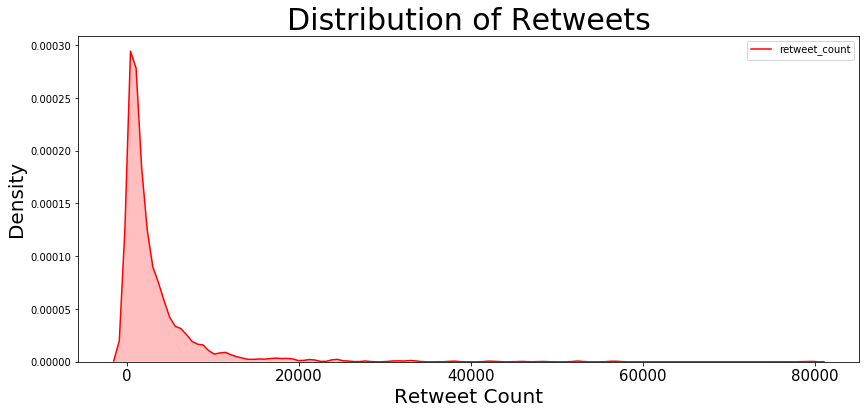

```python
plt.figure(figsize = (14,6))
sns.kdeplot(df_master.retweet_count, shade=True, color='r')
plt.title('Distribution of Retweets', fontsize=30)
plt.ylabel('Density',fontsize=20)
plt.xlabel('Retweet Count', fontsize=20)
plt.xticks(fontsize=15);
```

the plot below describe the favourite on the account:

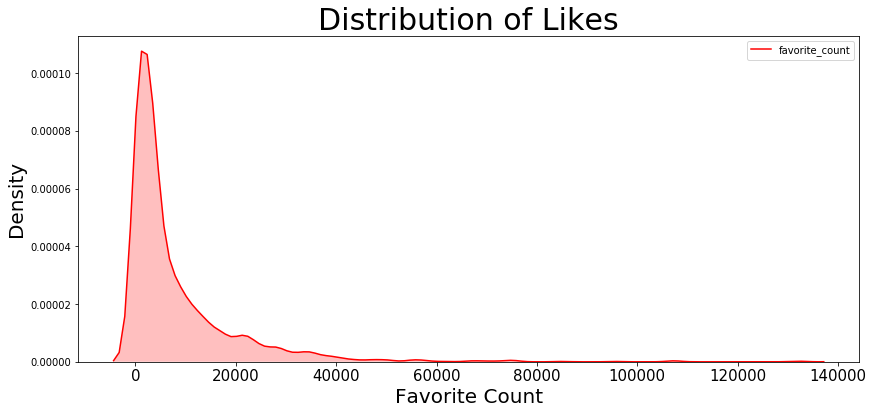

```python
plt.figure(figsize = (14,6))
sns.kdeplot(df_master.favorite_count, shade=True, color='r')
plt.title('Distribution of Likes', fontsize=30)
plt.ylabel('Density',fontsize=20)
plt.xlabel('Favorite Count', fontsize=20)
plt.xticks(fontsize=15);
```

the plot below shows us the most common stage of the dogs:

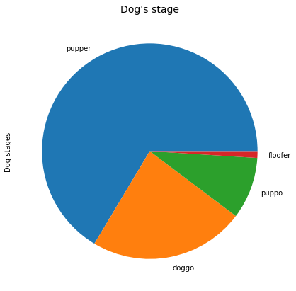

```python
df_master['Dog stages'].value_counts().plot(kind='pie', figsize=(7,7))
plt.title('Dog\'s stage' , size=14)
```

```python
df_master.rating_numerator.value_counts()
```

```
12      558
11      464
10      461
13      351
9       158
8       102
7        55
14       54
5        37
6        32
3        19
4        17
1         9
2         9
420       2
```

[output cut: 26 more lines]

what people usually use for twitter:

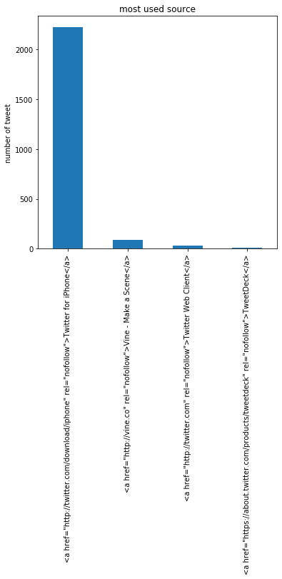

```python
plot = df_master['source'].value_counts().plot(kind = 'bar', figsize = (6,6))
plot.set_ylabel('number of tweet')
plt.title('most used source' , size=12)
```

the two plot below are for the dogs predection & dogs name:

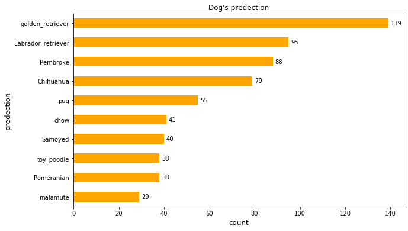

```python
# Dogs predection..


plt.figure(figsize=(10,6))
df_master['predection'].value_counts()[0:10].sort_values(ascending=True).plot(kind='barh' , color ='orange')

# declare the title of the plot and (x,y)
plt.xlabel('count',size=12)
plt.ylabel('predection', size=12)
plt.title('Dog\'s predection' , size=12)

x = df_master['predection'].value_counts()[0:10].sort_values(ascending=True).values
y= np.arange(0,10,1)

# to set the values on each bar
for x1, y1 in zip(x,y):
    plt.text(x1+1,y1,x1 , va='center')
```

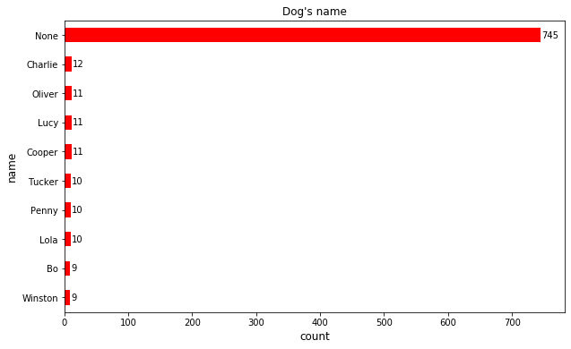

```python
# Dogs name..


plt.figure(figsize=(10,6))
df_master['name'].value_counts()[0:10].sort_values(ascending=True).plot(kind='barh' , color ='red')

# declare the title of the plot and (x,y)
plt.xlabel('count',size=12)
plt.ylabel('name', size=12)
plt.title('Dog\'s name' , size=12)

x = df_master['name'].value_counts()[0:10].sort_values(ascending=True).values
y= np.arange(0,10,1)

# to set the values on each bar
for x1, y1 in zip(x,y):
    plt.text(x1+1,y1,x1 , va='center')
```

the plot below for 'rating_numerator' to check which value is the highest:

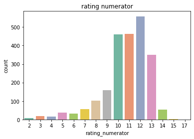

```python
sns.countplot(df_master[(df_master['rating_numerator']<20) & (df_master['rating_numerator']> 1)]['rating_numerator'],palette="Set2")
plt.title('rating numerator' , size=12)
```

to show the most dog has favourite:

```python
df_master.loc[df_master.favorite_count.idxmax()]
```

```
tweet_id                                                        822975315408461824
timestamp                                                2017-01-22 01:12:59+00:00
source                           <a href="http://twitter.com/download/iphone" r...
text                             This is Albus. He's soaked as h*ck. Seems to h...
expanded_urls                    https://twitter.com/dog_rates/status/822975315...
rating_numerator                                                                12
rating_denominator                                                              10
name                                                                         Albus
text_url                                                   https://t.co/yUM8jYStuG
Dog stages                                                                     NaN
tweet_id                                                               6.73919e+17
jpg_url                            https://pbs.twimg.com/media/CVo-JuMWwAAet6F.jpg
img_num                                                                          1
predection                                                         jack-o'-lantern
p1_configration                                                           0.172079
p1_dog                                                                       False
contributors                                                                  None
coordinates                                                                   None
created_at                                          Sat Jan 21 18:26:02 +0000 2017
display_text_range                                                         [0, 87]
entities                         {'hashtags': [{'text': 'WomensMarch', 'indices...
extended_entities                {'media': [{'id': 822872859181809664, 'id_str'...
favorite_count                                                              132810
favorited                                                                    False
full_text                        Here's a super supportive puppo participating ...
geo                                                                           None
tweet_id                                                               8.22873e+17
id_str                                                          822872901745569793
in_reply_to_screen_name                                                       None
in_reply_to_status_id                                                          NaN
in_reply_to_status_id_str                                                     None
in_reply_to_user_id                                                            NaN
in_reply_to_user_id_str                                                       None
is_quote_status                                                              False
lang                                                                            en
place                                                                         None
possibly_sensitive                                                           False
possibly_sensitive_appealable                                                False
quoted_status                                                                  NaN
quoted_status_id                                                               NaN
quoted_status_id_str                                                           NaN
retweet_count                                                                48265
retweeted                                                                    False
retweeted_status                                                               NaN
source                           <a href="http://twitter.com/download/iphone" r...
truncated                                                                    False
user                             {'id': 4196983835, 'id_str': '4196983835', 'na...
Name: 412, dtype: object
```

# Reference:

- pandas.DataFrame.drop_duplicates https://pandas.pydata.org/docs/reference/api/pandas.DataFrame.drop_duplicates.html
- Python Pandas Tricks: 3 Best Methods To Join Datasets https://towardsdatascience.com/python-pandas-tricks-3-best-methods-4a909843f5bc
- Python | Pandas Series.str.extract() https://www.geeksforgeeks.org/python-pandas-series-str-extract/